# Intro to R: Visualization Basics

## Scatterplot

We’ll use the `gapminder` data here and make a scatterplot of life expectancy and GDP per capita in 2002.

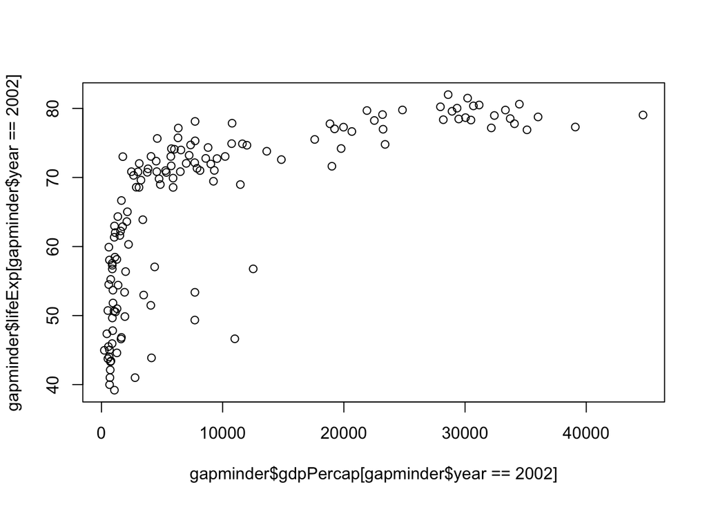

```r
plot(x=gapminder$gdpPercap[gapminder$year==2002],
     y=gapminder$lifeExp[gapminder$year==2002])
```

Looks like there’s an exponential function here. Log GDP per capita.

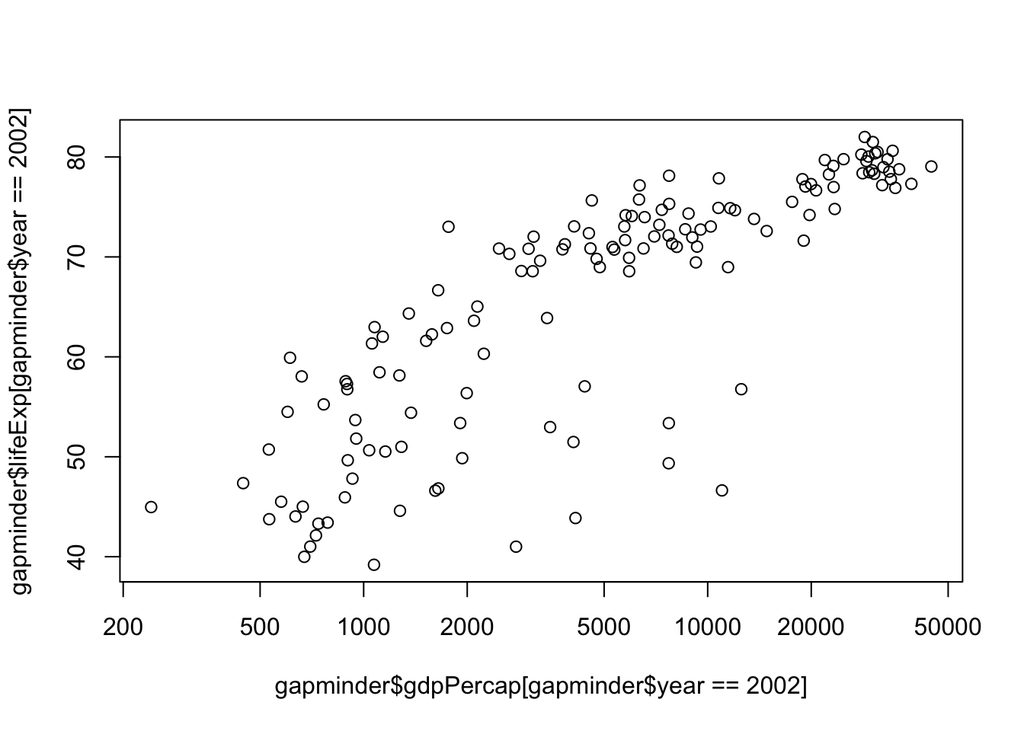

```r
plot(x=gapminder$gdpPercap[gapminder$year==2002],
     y=gapminder$lifeExp[gapminder$year==2002],
     log="x")
```

This `log` argument can be found in the help page for `plot.default`.

Make point size a function of population. Use a formula to scale relatively to area, not diameter. Use transparency for overlapping points.

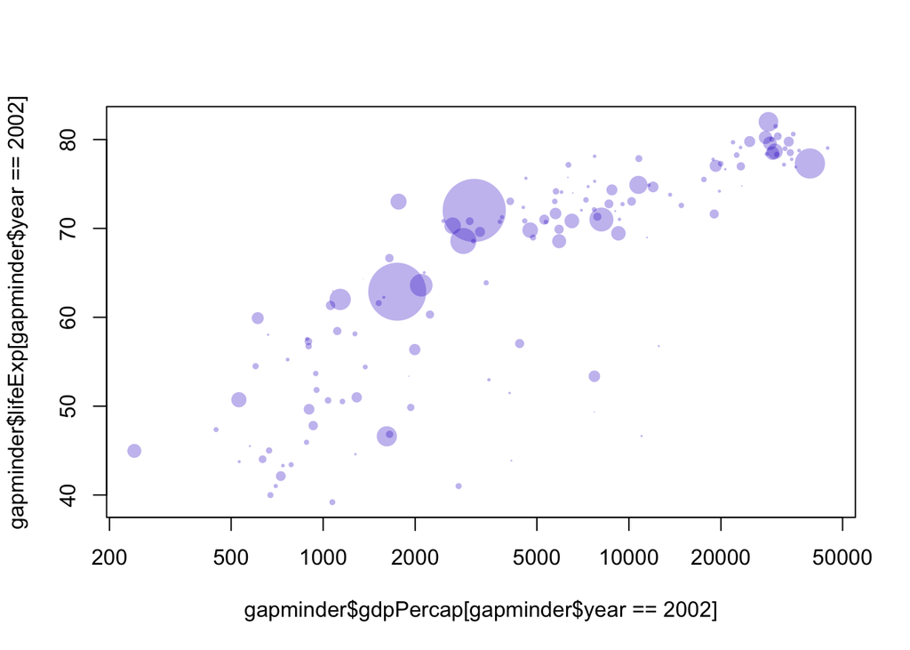

```r
plot(x=gapminder$gdpPercap[gapminder$year==2002],
     y=gapminder$lifeExp[gapminder$year==2002],
     log="x",
     pch=16, cex=sqrt(1e-7*gapminder$pop[gapminder$year==2007]/pi),
     col=rgb(.2, 0, .8, alpha=.3))
```

## Save

There’s an export button in the plot window; otherwise you have to plot to a specific graphics device.

```r
pdf("plot1.pdf", width=6, height=4)
plot(x=gapminder$gdpPercap[gapminder$year==2002],
     y=gapminder$lifeExp[gapminder$year==2002],
     log="x")
dev.off()
```